# STAT/497 - QUIZ 1

BETÜL YILDIRIM

2024-12-12

## A

```r
#install.packages("timeSeriesDataSets")
library(timeSeriesDataSets)
data("jj_ts")
```

```r
head(jj_ts)
```

```
## [1] 0.71 0.63 0.85 0.44 0.61 0.69
```

```r
class(jj_ts)
```

```
## [1] "ts"
```

```r
str(jj_ts)
```

```
##  Time-Series [1:84] from 1960 to 1981: 0.71 0.63 0.85 0.44 0.61 0.69 0.92 0.55 0.72 0.77 ...
```

```r
summary(jj_ts)
```

```
##    Min. 1st Qu.  Median    Mean 3rd Qu.    Max.
##   0.440   1.248   3.510   4.800   7.133  16.200
```

```r
sum(is.na(jj_ts))
```

```
## [1] 0
```

- There is no missing value.

```r
frequency(jj_ts)
```

```
## [1] 4
```

- It is quarterly dataset.

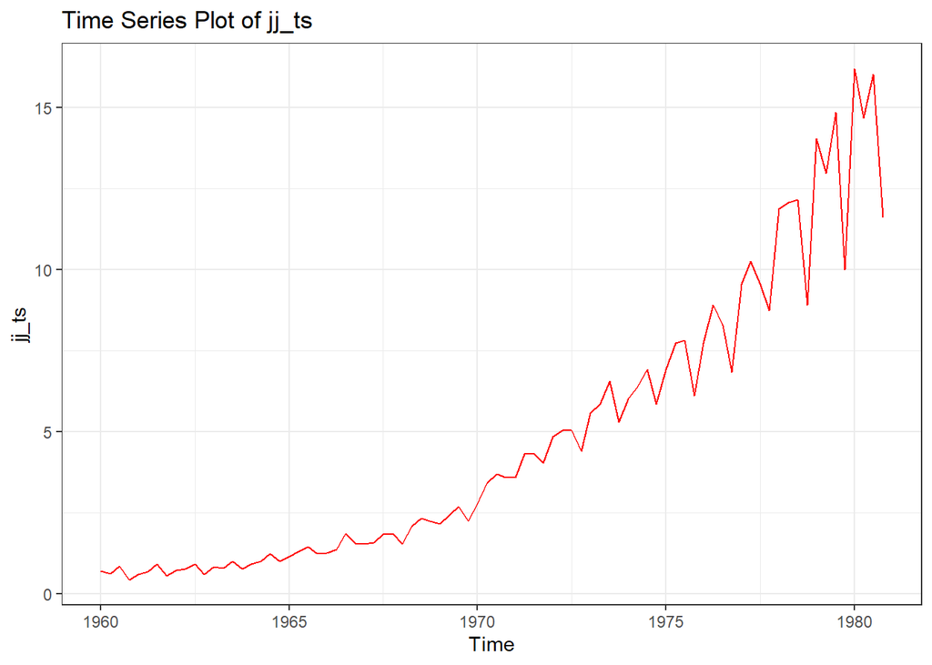

```r
library(ggplot2)
library(forecast)
autoplot(jj_ts,main="Time Series Plot of jj_ts ",col="red")+theme_bw()
```

- There is an increasing trend. Mean is not constant over time. Threre is a multiplicative seasonality in this data. Volatility exists. Variance is not stable over time. The series is not stationary.

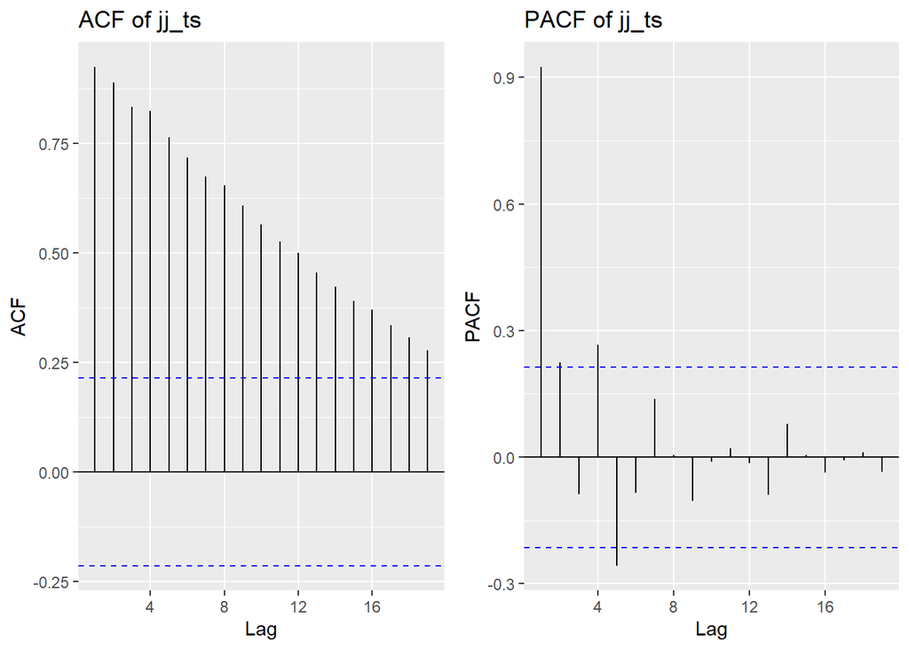

```r
library(gridExtra)
p1<-ggAcf(jj_ts,main="ACF of jj_ts")
p2<-ggPacf(jj_ts,main="PACF of jj_ts")
grid.arrange(p1,p2,nrow=1)
```

- There is a slow linear decay in ACF plot. It indicates that the series is not staionary. Also, we can see in ACF plot, there are significant spikes in lag 4, 8 and 12(there is slow decay in thsese spikes) since probably we have quarterly seasonality in this dataset. No need to interpret PACF.

## B - Split the data into train and test set.

```r
traindata<-window(jj_ts ,end=c(1978,4))
testdata<-window(jj_ts ,start=c(1979,1))
length(traindata)
```

```
## [1] 76
```

```r
length(jj_ts)
```

```
## [1] 84
```

```r
length(testdata)
```

```
## [1] 8
```

```r
lambda<-BoxCox.lambda(traindata)
lambda
```

```
## [1] 0.2557461
```

```r
traindata_bc<-BoxCox(traindata,lambda)
```

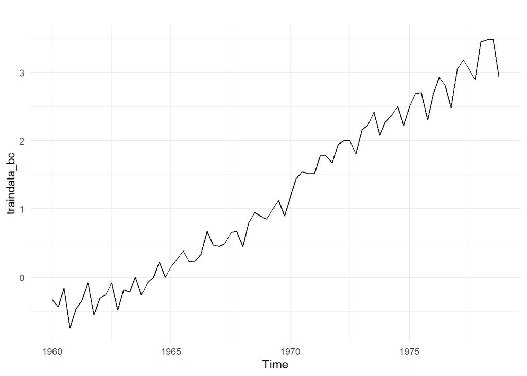

```r
autoplot(traindata_bc)+theme_minimal()
```

- Variance is more stable by using boxcox transformation.

```r
traindata_bc_clean<-tsclean(traindata_bc)
```

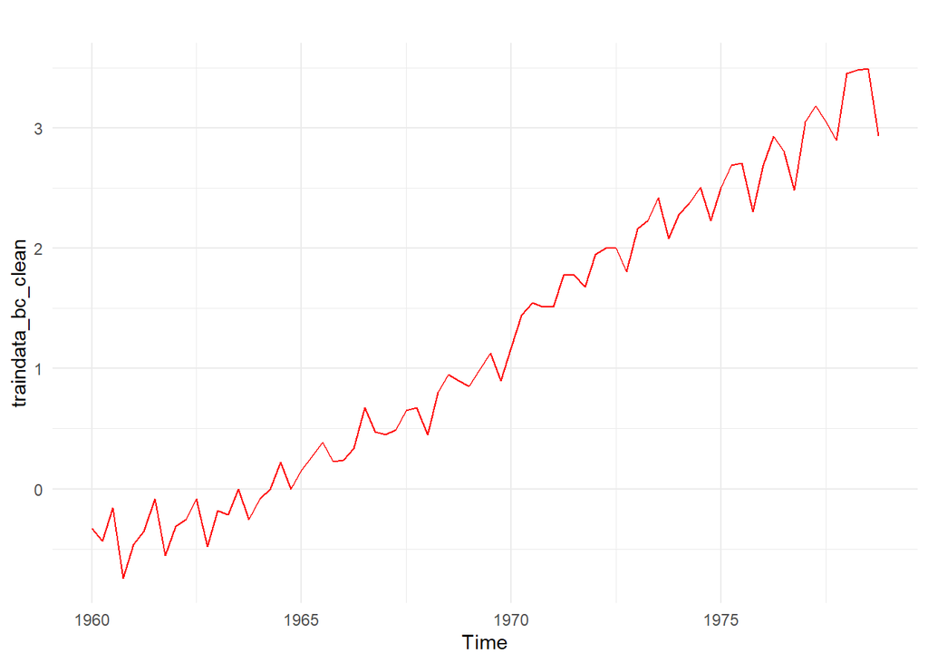

```r
autoplot(traindata_bc_clean)+autolayer(traindata_bc,color="red")+theme_minimal()
```

- The function does not detect the outlier in the data.

## C and D

- The series shows increasing trend. It is not stationary. To be sure that formal test are applied.

```r
library(tseries)
kpss.test(traindata_bc_clean,null="Level")
```

```
##
##  KPSS Test for Level Stationarity
##
## data:  traindata_bc_clean
## KPSS Level = 1.9783, Truncation lag parameter = 3, p-value = 0.01
```

- The p value is less than alpha so we can reject the null hypothesis which is series is stationary. We can conclude that the series is not stationary.

```r
kpss.test(traindata_bc_clean,null="Trend")
```

```
##
##  KPSS Test for Trend Stationarity
##
## data:  traindata_bc_clean
## KPSS Trend = 0.32856, Truncation lag parameter = 3, p-value = 0.01
```

- The p value is less than alpha so we can reject the null hypothesis which is series has deterministic trend so we can conclude that the series has stochastic trend.

```r
library(pdR)
test<-HEGY.test(traindata_bc_clean, itsd=c(1,1,0))
test$stats
```

```
##             Stat.    p-value
## tpi_1   -2.914149 0.10000000
## tpi_2   -1.768191 0.07322985
## Fpi_3:4  1.068415 0.10000000
## Fpi_2:4  1.754040         NA
## Fpi_1:4  3.863691         NA
```

- According to the HEGY test, we have both regular unit root and seasonal unit root. Therefore, we will take differences.

```r
ndiffs(traindata_bc_clean)
```

```
## [1] 1
```

```r
nsdiffs(traindata_bc_clean)
```

```
## [1] 1
```

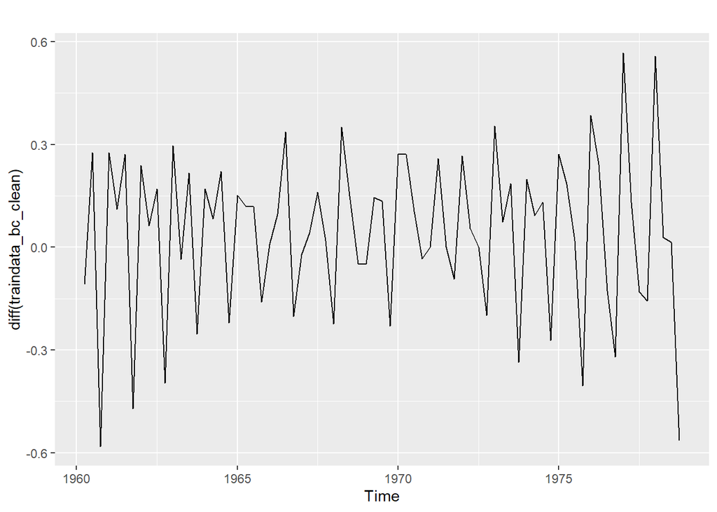

```r
autoplot(diff(traindata_bc_clean))
```

- Taking regular differencing:

```r
test2<-HEGY.test(diff(traindata_bc_clean), itsd=c(0,0,0))
test2$stats
```

```
##              Stat. p-value
## tpi_1   -0.2748483     0.1
## tpi_2   -0.7508217     0.1
## Fpi_3:4  0.9006176     0.1
## Fpi_2:4  0.8594646      NA
## Fpi_1:4  0.6668461      NA
```

- There is still regular and seasonal unit root.
- Seasonal differencing:

```r
test3<-HEGY.test(diff(traindata_bc_clean,4), itsd=c(0,0,0))
test3$stats
```

```
##             Stat.    p-value
## tpi_1   -1.233324 0.10000000
## tpi_2   -3.749116 0.01016431
## Fpi_3:4 20.942762 0.01000000
## Fpi_2:4 23.112383         NA
## Fpi_1:4 17.383799         NA
```

- There is unit root.
- Taking both regular and seasonal difference:

```r
test3<-HEGY.test(diff(diff(traindata_bc_clean),4), itsd=c(0,0,0))
test3$stats
```

```
##             Stat.    p-value
## tpi_1   -6.779353 0.01000000
## tpi_2   -4.792040 0.01033289
## Fpi_3:4 26.911255 0.01000000
## Fpi_2:4 24.092262         NA
## Fpi_1:4 38.232917         NA
```

- There is no seasonal root and unit root.

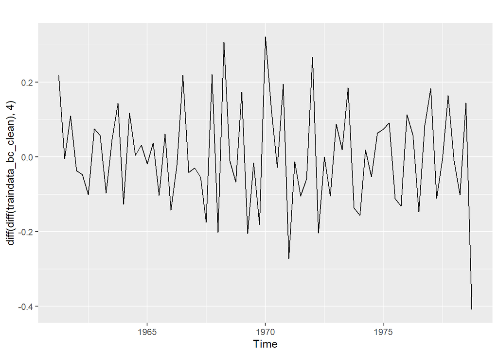

```r
autoplot(diff(diff(traindata_bc_clean),4))
```

- The series seems stationary.

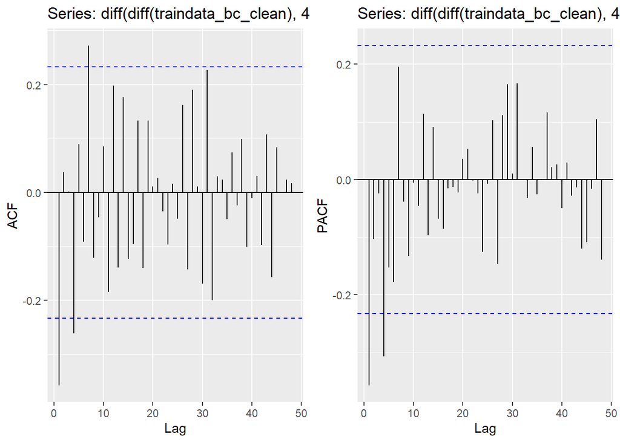

```r
library(gridExtra)
p1<-ggAcf(diff(diff(traindata_bc_clean),4),lag.max = 48)
p2<-ggPacf(diff(diff(traindata_bc_clean),4),lag.max = 48)
grid.arrange(p1,p2,ncol=2)
```

```r
kpss.test(diff(diff(traindata_bc_clean),4) ,null="Level")
```

```
##
##  KPSS Test for Level Stationarity
##
## data:  diff(diff(traindata_bc_clean), 4)
## KPSS Level = 0.11937, Truncation lag parameter = 3, p-value = 0.1
```

- The p value is greater than alpha so fail to reject h0. After regular and seasonal differencing, the series is now stationary.

```r
pp.test(diff(diff(traindata_bc_clean),4))
```

```
##
##  Phillips-Perron Unit Root Test
##
## data:  diff(diff(traindata_bc_clean), 4)
## Dickey-Fuller Z(alpha) = -89.454, Truncation lag parameter = 3, p-value
## = 0.01
## alternative hypothesis: stationary
```

- Since the p value is less than alpha so we can reject h0 which is the series has unit root. We conclude that the series is stationary.

## E- Identify a proper ARMA, ARIMA or SARIMA models.

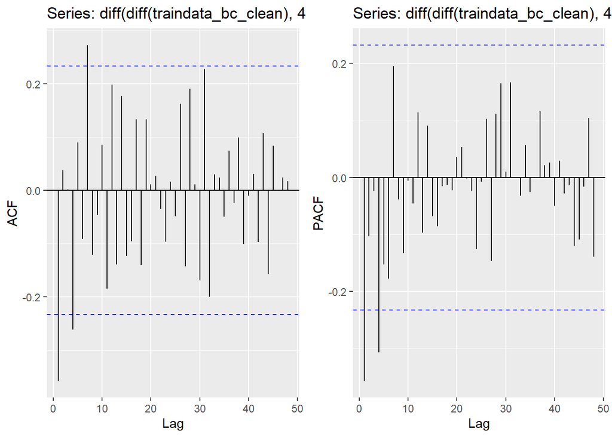

```r
library(gridExtra)
p1<-ggAcf(diff(diff(traindata_bc_clean),4),lag.max = 48)
p2<-ggPacf(diff(diff(traindata_bc_clean),4),lag.max = 48)
grid.arrange(p1,p2,ncol=2)
```

- According to he ACF and PACF plot, we have stationary series and we can suggest models:

SARIMA(0,1,1)(0,1,1)4 SARIMA(0,1,1)(1,1,1)4

SARIMA(1,1,1)(0,1,1)4 SARIMA(1,1,1)(1,1,1)4

## F- Find the best model and interpret the results.

```r
auto.arima(traindata_bc_clean)
```

```
## Series: traindata_bc_clean
## ARIMA(0,1,1)(0,1,1)[4]
##
## Coefficients:
##           ma1     sma1
##       -0.6400  -0.3818
## s.e.   0.1066   0.1130
##
## sigma^2 = 0.0136:  log likelihood = 52.2
## AIC=-98.39   AICc=-98.03   BIC=-91.6
```

```r
fit1<-Arima(traindata_bc_clean,order = c(0, 1, 1), seasonal = c(0, 1, 1))
fit1
```

```
## Series: traindata_bc_clean
## ARIMA(0,1,1)(0,1,1)[4]
##
## Coefficients:
##           ma1     sma1
##       -0.6400  -0.3818
## s.e.   0.1066   0.1130
##
## sigma^2 = 0.0136:  log likelihood = 52.2
## AIC=-98.39   AICc=-98.03   BIC=-91.6
```

```r
fit2<-Arima(traindata_bc_clean,order = c(0, 1, 1), seasonal = c(1, 1, 1))
fit2
```

```
## Series: traindata_bc_clean
## ARIMA(0,1,1)(1,1,1)[4]
##
## Coefficients:
##           ma1     sar1     sma1
##       -0.6351  -0.1611  -0.2489
## s.e.   0.1045   0.2875   0.2785
##
## sigma^2 = 0.01374:  log likelihood = 52.34
## AIC=-96.68   AICc=-96.07   BIC=-87.63
```

```r
fit3<-Arima(traindata_bc_clean,order = c(1, 1, 1), seasonal = c(0, 1, 1))
fit3
```

```
## Series: traindata_bc_clean
## ARIMA(1,1,1)(0,1,1)[4]
##
## Coefficients:
##          ar1      ma1     sma1
##       0.1229  -0.7159  -0.3625
## s.e.  0.2052   0.1512   0.1230
##
## sigma^2 = 0.01372:  log likelihood = 52.38
## AIC=-96.75   AICc=-96.15   BIC=-87.7
```

```r
fit4<-Arima(traindata_bc_clean,order = c(1, 1, 1), seasonal = c(1, 1, 1))
fit4
```

```
## Series: traindata_bc_clean
## ARIMA(1,1,1)(1,1,1)[4]
##
## Coefficients:
##          ar1      ma1     sar1     sma1
##       0.0987  -0.6974  -0.1203  -0.2669
## s.e.  0.2172   0.1627   0.3161   0.2921
##
## sigma^2 = 0.0139:  log likelihood = 52.44
## AIC=-94.89   AICc=-93.97   BIC=-83.57
```

```r
models <- list(model1 = fit1, model2 = fit2, model3 = fit3,model=fit4)
```

```r
check_significance <- function(model) {
  coefficients <- coef(model)
  standard_errors <- sqrt(diag(vcov(model)))
  z_values <- abs(coefficients / standard_errors)
  significant <- z_values > 2
  result <- data.frame(
    Coefficient = names(coefficients),
    Estimate = coefficients,
    Std_Error = standard_errors,
    Z_Value = z_values,
    Significant = significant
  )
  return(result)
}
```

```r
comparison_results <- lapply(models, function(model) {
  list(
    Significance = check_significance(model),
    AIC = AIC(model),
    BIC = BIC(model),
    Log_Likelihood = logLik(model)
  )
})
print(comparison_results)
```

```
## $model1
## $model1$Significance
##      Coefficient   Estimate Std_Error  Z_Value Significant
## ma1          ma1 -0.6399516 0.1066055 6.002991        TRUE
## sma1        sma1 -0.3817547 0.1129682 3.379313        TRUE
##
## $model1$AIC
## [1] -98.39063
##
## $model1$BIC
## [1] -91.60259
##
## $model1$Log_Likelihood
## 'log Lik.' 52.19532 (df=3)
##
##
## $model2
## $model2$Significance
##      Coefficient   Estimate Std_Error   Z_Value Significant
## ma1          ma1 -0.6351200 0.1044980 6.0778213        TRUE
## sar1        sar1 -0.1610884 0.2875496 0.5602110       FALSE
## sma1        sma1 -0.2488638 0.2785110 0.8935511       FALSE
##
## $model2$AIC
## [1] -96.67986
##
## $model2$BIC
## [1] -87.62914
##
## $model2$Log_Likelihood
## 'log Lik.' 52.33993 (df=4)
##
##
## $model3
## $model3$Significance
##      Coefficient   Estimate Std_Error   Z_Value Significant
## ar1          ar1  0.1229353 0.2052041 0.5990878       FALSE
## ma1          ma1 -0.7158616 0.1512427 4.7331992        TRUE
## sma1        sma1 -0.3624525 0.1229711 2.9474608        TRUE
##
```

[output cut: 11 more lines]

```
## $model$Significance
##      Coefficient   Estimate Std_Error   Z_Value Significant
## ar1          ar1  0.0987319 0.2172194 0.4545262       FALSE
## ma1          ma1 -0.6974220 0.1627038 4.2864507        TRUE
## sar1        sar1 -0.1202901 0.3161192 0.3805213       FALSE
## sma1        sma1 -0.2668656 0.2921191 0.9135506       FALSE
##
## $model$AIC
## [1] -94.88836
##
## $model$BIC
## [1] -83.57496
##
## $model$Log_Likelihood
## 'log Lik.' 52.44418 (df=5)
```

```r
fit1
```

```
## Series: traindata_bc_clean
## ARIMA(0,1,1)(0,1,1)[4]
##
## Coefficients:
##           ma1     sma1
##       -0.6400  -0.3818
## s.e.   0.1066   0.1130
##
## sigma^2 = 0.0136:  log likelihood = 52.2
## AIC=-98.39   AICc=-98.03   BIC=-91.6
```

- fit1 has significant parameters and ıts AIC value is smallest. We should continue fit1 model.

## G- Apply Diagnostic Checking. Interpret the results.

```r
residuals= resid(fit1)
```

# Normality of Errors:

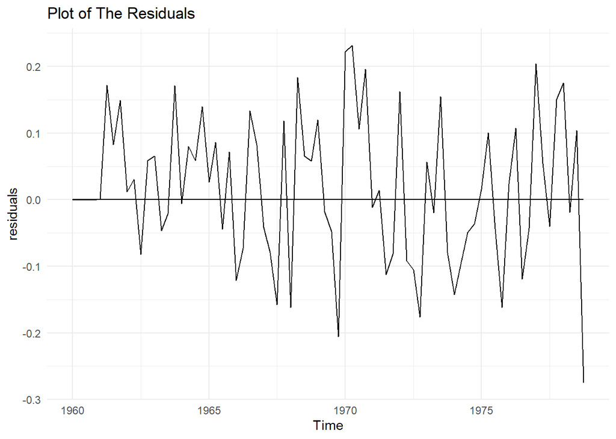

```r
autoplot(residuals)+geom_line(y=0)+theme_minimal()+ggtitle("Plot of The Residuals")
```

- They are scattered around zero and it can be interpreted as zero mean.
- QQ PLOT:

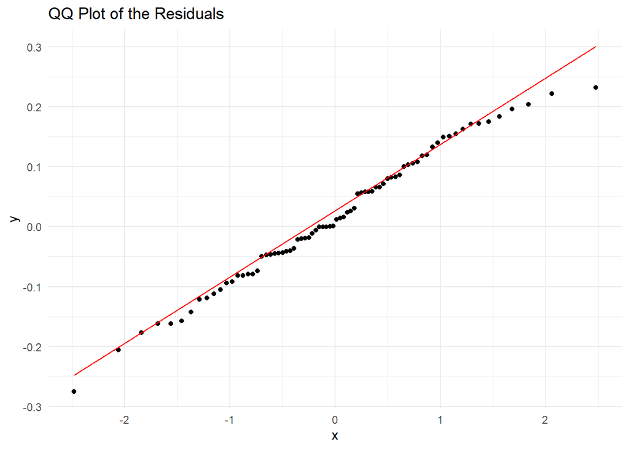

```r
ggplot(residuals, aes(sample = residuals)) +stat_qq()+geom_qq_line(col="red")+ggtitle("QQ Plot of the Residuals")+theme_minimal()
```

- Most of the residuals lie close to the red line, indicating that they generally follow a normal distribution. There are slight deviations at the tails. The residuals appear mostly normally distributed, with minor deviations in the tails.

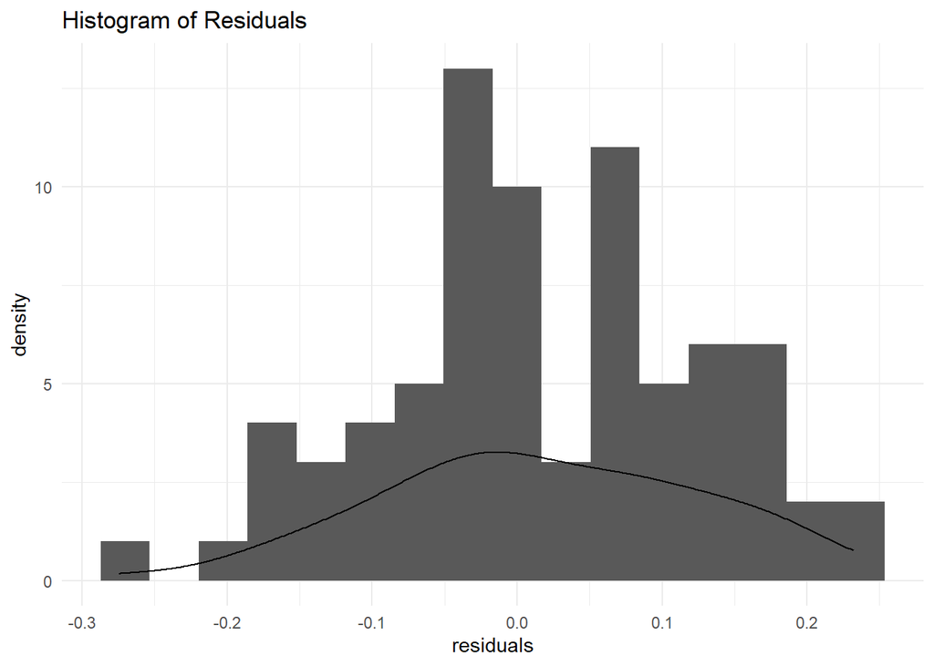

```r
ggplot(residuals,aes(x=residuals))+geom_histogram(bins=16)+geom_density()+ggtitle("Histogram of Residuals")+theme_minimal()
```

```r
summary(residuals)
```

```
##      Min.   1st Qu.    Median      Mean   3rd Qu.      Max.
## -0.274808 -0.048094  0.006491  0.016270  0.101253  0.231931
```

- The residuals are generally small, spread around zero.

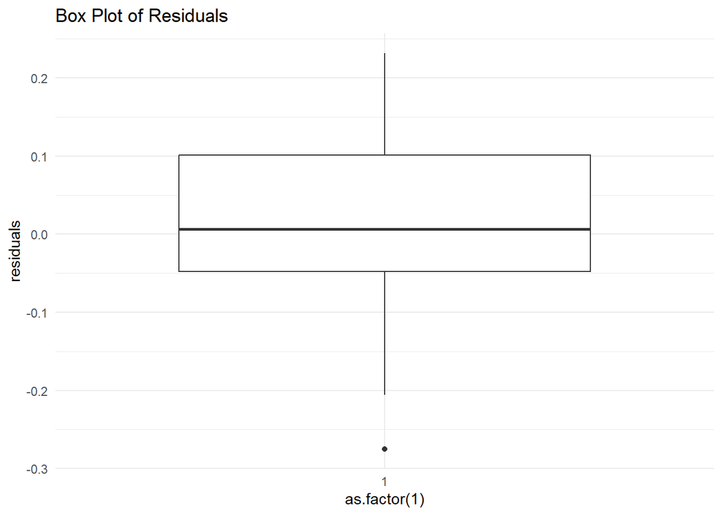

```r
ggplot(residuals,aes(y=residuals,x=as.factor(1)))+geom_boxplot()+ggtitle("Box Plot of Residuals")+theme_minimal()
```

- The boxplot shows that the data seems normal. The residuals are generally well-behaved, with most of them scatered close to zero.

**Formal Tests for test the normality of residuals :**

- Jarque Bera Test

```r
library(tseries)
jarque.bera.test(residuals)
```

```
##
##  Jarque Bera Test
##
## data:  residuals
## X-squared = 0.97164, df = 2, p-value = 0.6152
```

- According to the Jarque Bera test, the p value(0.6152) is gretar than alpha(0.05). We fail to reject h0 which is residuals have normal distribution. We conclude that residuals have normal distribution.
- Shapiro-Wilk Test

```r
shapiro.test(residuals)
```

```
##
##  Shapiro-Wilk normality test
##
## data:  residuals
## W = 0.98809, p-value = 0.7025
```

- According to the Shapiro Wilk test, the p value(0.7025) is gretar than alpha(0.05). We fail to reject h0 which is residuals have normal distribution. We conclude that residuals have normal distribution.

# Detection of the Serial Autocorrelation:

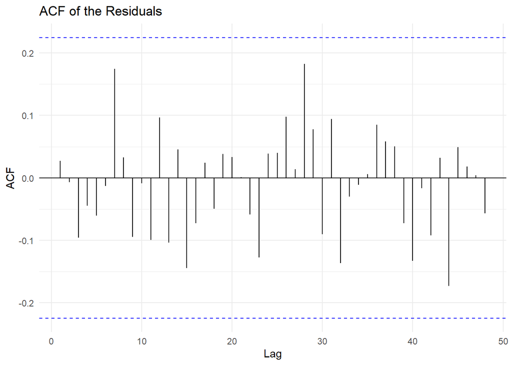

```r
ggAcf(as.vector(residuals),main="ACF of the Residuals",lag = 48)+theme_minimal()
```

- All spikes are in the WN band so the residuals are uncorrelated.
- Formal tests:
- Breusch-Godfrey Test:

```r
library(TSA)
m = lm(residuals ~ 1+zlag(residuals))
```

```r
library(lmtest)
bgtest(m,order=15)
```

```
##
##  Breusch-Godfrey test for serial correlation of order up to 15
##
## data:  m
## LM test = 9.9153, df = 15, p-value = 0.825
```

- Since p value(0.825) is greater than alpha, we have conclude that the residuals of the model are uncorrelated, according to results of Breusch-Godfrey Test.
- Box-Ljung Test:

```r
Box.test(residuals,lag=15,type = c("Ljung-Box"))
```

```
##
##  Box-Ljung test
##
## data:  residuals
## X-squared = 9.8279, df = 15, p-value = 0.8304
```

- Since p value(0.8304) is greater than alpha, we have conclude that the residuals of the model are uncorrelated, according to results of Box-Ljung test.

# Detecting Heteroscedasticity:

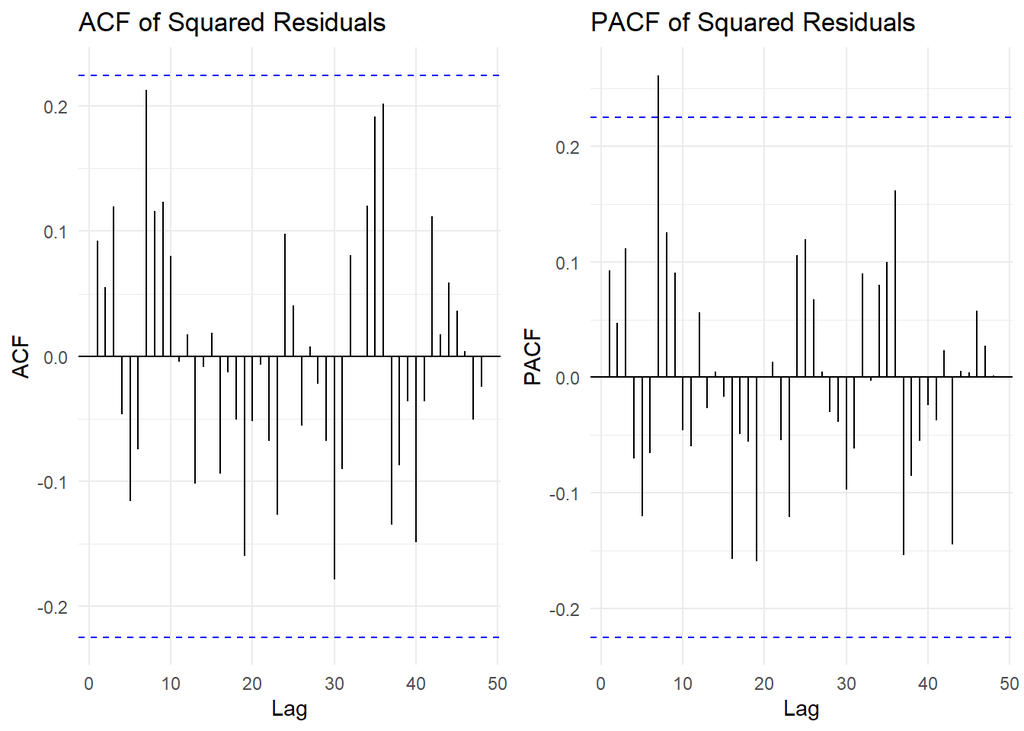

```r
resisuals_squared=residuals^2
g1<-ggAcf(as.vector(resisuals_squared), lag.max = 48)+theme_minimal()+ggtitle("ACF of Squared Residuals")
g2<-ggPacf(as.vector(resisuals_squared), lag.max = 48)+theme_minimal()+ggtitle("PACF of Squared Residuals")
grid.arrange(g1,g2,ncol=2)
```

- Both plots shows that almost all spikes are in of the white noise bands that is an indication of homoscedasticity. To be sure, we can apply formal test.
- Formal test:
- Breusch Pagan Test

```r
library(lmtest)
m = lm(residuals ~ traindata_bc_clean+zlag(traindata_bc_clean)+zlag(traindata_bc_clean,2))
bptest(m)
```

```
##
##  studentized Breusch-Pagan test
##
## data:  m
## BP = 3.4357, df = 3, p-value = 0.3292
```

- Since p value is greater than α, we fail to reject Ho. Therefore, we can say that we have enough evidence to claim that there is no heteroscedasticity problem, according to results of Breusch-Pagan test.
- White test:

```r
m1 = lm(residuals ~ traindata_bc_clean+zlag(traindata_bc_clean)+zlag(traindata_bc_clean,2)+zlag(traindata_bc_clean)^2+zlag(traindata_bc_clean,2)^2+zlag(traindata_bc_clean)*zlag(traindata_bc_clean,2))
bptest(m1)
```

```
##
##  studentized Breusch-Pagan test
##
## data:  m1
## BP = 4.0167, df = 4, p-value = 0.4038
```

- Since p value is greater than alpha, we fail reject Ho. Therefore, we can say that we have enough evidence to claim that there is no heteroscedasticity problem, according to results of studentized Breusch-Pagan test.
- Engle’s ARCH Test:

```r
#install.packages("FinTS")
library(FinTS)
ArchTest(resisuals_squared)
```

```
##
##  ARCH LM-test; Null hypothesis: no ARCH effects
##
## data:  resisuals_squared
## Chi-squared = 14.332, df = 12, p-value = 0.28
```

- The p value is greater than alpha, we fail to reject H0 which is residuals exhibits no ARCH effects . Therefore, we can conclude that there is no presence of ARCH effects.

## H - obtain forecast values from the model and calculate accuracy

```r
f<-forecast(fit1,h=8)
f
```

```
##         Point Forecast    Lo 80    Hi 80    Lo 95    Hi 95
## 1979 Q1       3.634630 3.485182 3.784079 3.406069 3.863192
## 1979 Q2       3.713140 3.554300 3.871981 3.470215 3.956065
## 1979 Q3       3.682911 3.515204 3.850617 3.426425 3.939396
## 1979 Q4       3.248413 3.072285 3.424540 2.979049 3.517776
## 1980 Q1       3.885051 3.656148 4.113954 3.534974 4.235128
## 1980 Q2       3.963561 3.718656 4.208467 3.589010 4.338112
## 1980 Q3       3.933331 3.673406 4.193256 3.535811 4.330852
## 1980 Q4       3.498833 3.224711 3.772956 3.079599 3.918067
```

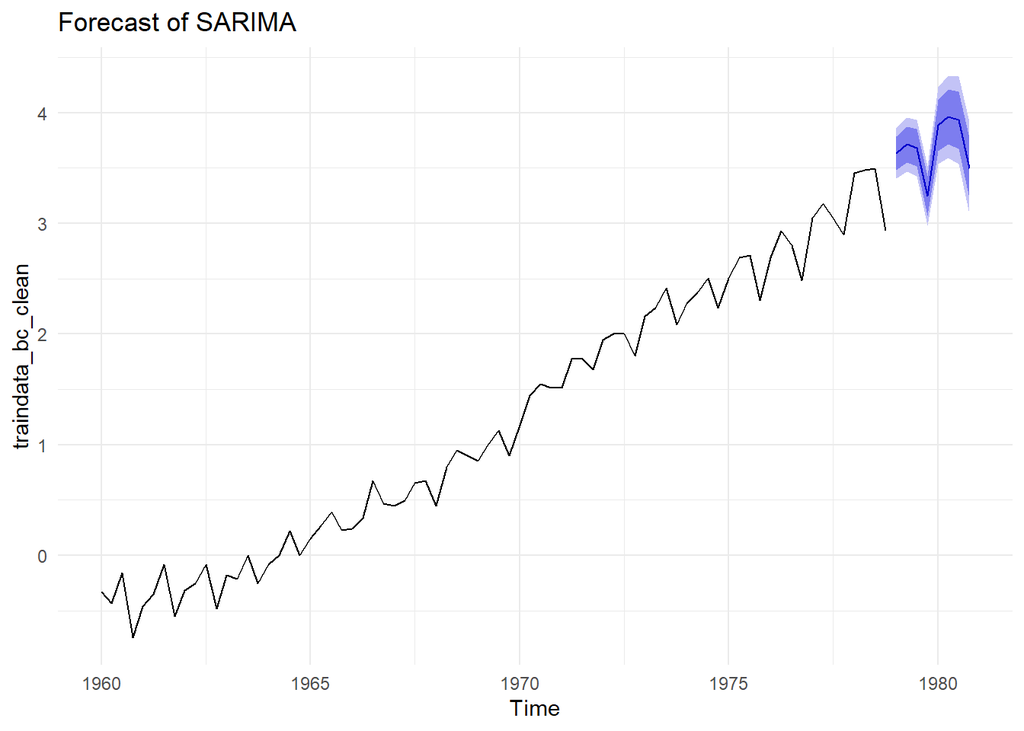

```r
autoplot(f)+theme_minimal()+ggtitle("Forecast of SARIMA")
```

```r
f_t<-InvBoxCox(f$mean,lambda)
```

```r
accuracy(f_t,testdata)
```

```
##                 ME      RMSE       MAE      MPE     MAPE       ACF1 Theil's U
## Test set 0.2456933 0.9550685 0.9022647 1.071834 6.463388 -0.8739134 0.2600572
```

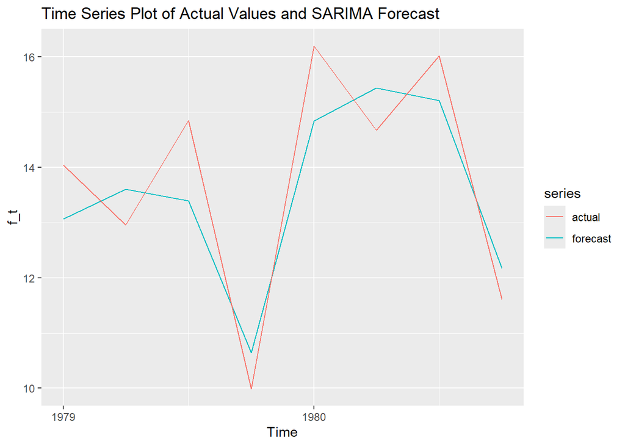

```r
autoplot(f_t,main=c("Time Series Plot of Actual Values and SARIMA Forecast"), series="forecast" ) + autolayer(testdata,series = "actual")
```

- Indicates the average absolute percentage error between the predictions and actual values. A lower MAPE is considered a good result. Here, a value of 6.46% suggests strong accuracy in predictions.
- A smaller RMSE indicates better model accuracy. Here, 0.9551 suggests moderate error magnitude.
- Overall, we can say that the model is effective in forecasting.